# Trabalho Final

Eduardo Santiago

17/12/2019

# Análise dos Suicídios no Brasil

## Objetivo

Essa análise tem como principal objetivo encontrar os fatores de risco para suicídio no Brasil e prever a evolução desses dados para os próximos anos.

## A Base de Dados

Nessa análise será usada a base de dados de mortalidade da **OMS** Mortality, ICD-10. Ela é organizada pelo código dos países como variáveis categóricas e está em formato **long**. Com os dados dos países, outras variáveis categóricas são o tipo de morte e o gênero. Com isso, o número de mortes é separado por faixas-etárias padronizadas pela **OMS**.

## Fonte dos Dados

Os dados foram obtidos do site internacional da OMS https://www.who.int/healthinfo/statistics/mortality_rawdata/en/ Onde eles podem ser baixado em formato “puro”, como dois arquivos com mais de 10Mb para serem tratados. Eles vem como arquivos CSV que, após terem as causas da morte e países desejados selecionados, serão unidos e transformados em um único arquivo. Agilizando o tratamento dos dados.

## Dicionário de Dados

O dicionário de dados também está no link https://www.who.int/healthinfo/statistics/mortality_rawdata/en/ Apesar do dicionário conter as informações sobre todas as bases de dados, nessa sessão só serão exibidas as tabelas e linhas utilizadas.

## Perguntas em Potencial

- Existe uma diferença significativa entre as taxas de suicídio entre os gêneros?
- Quais são as categorias com maior chance de cometerem suicídios?
- Utilizando um modelo de regressão linear, as categorias em mais risco estão com o número de suicídios aumentando ou diminuindo?

#Análise Exploratória

# Análise Exploratória dos Suicídios no Brasil

Este relatório irá abordar insights sobre o número de suicídios no Brasil, os métodos mais utilizados e que categorias estão em mais risco.

##Perguntas: 1 - Quem cometeu mais suicídios? Existe uma diferença significativa? 2 - Existe uma preferência por métodos de suicídio por gênero? 3 - Qual a faixa etária mais suicida?

##1 Quem cometeu mais suicídios? Existe uma diferença significativa?

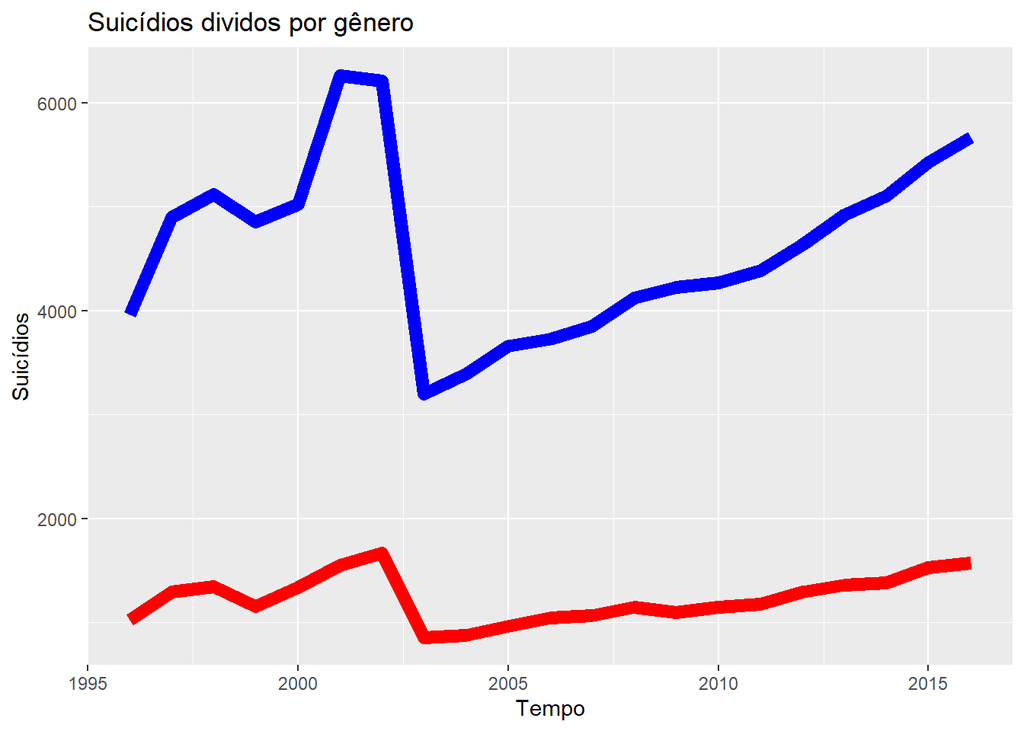

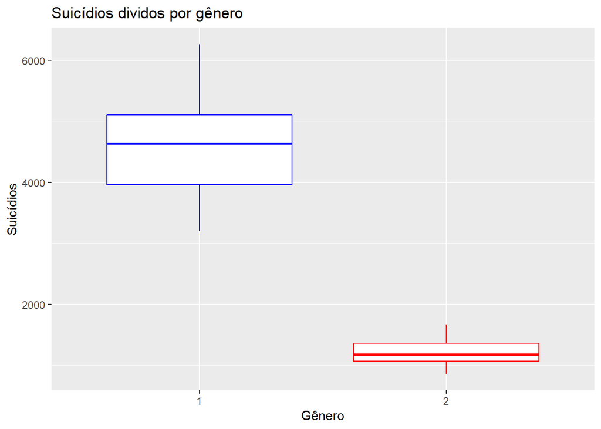

É possível perceber uma diferença significativa no número de suicídios entre homens(1) e mulheres(2)

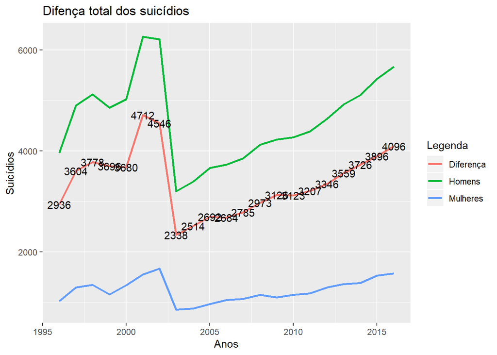

Neste gráfico temos a diferença “homens-mulheres” no mesmo gráfico, representada por uma linha entre os dois.

Assim sendo, é possível determinar uma diferença significativa entre a taxa de suicídio de homens e mulheres.

##2 Existe uma preferência por métodos de suicídio por gênero?

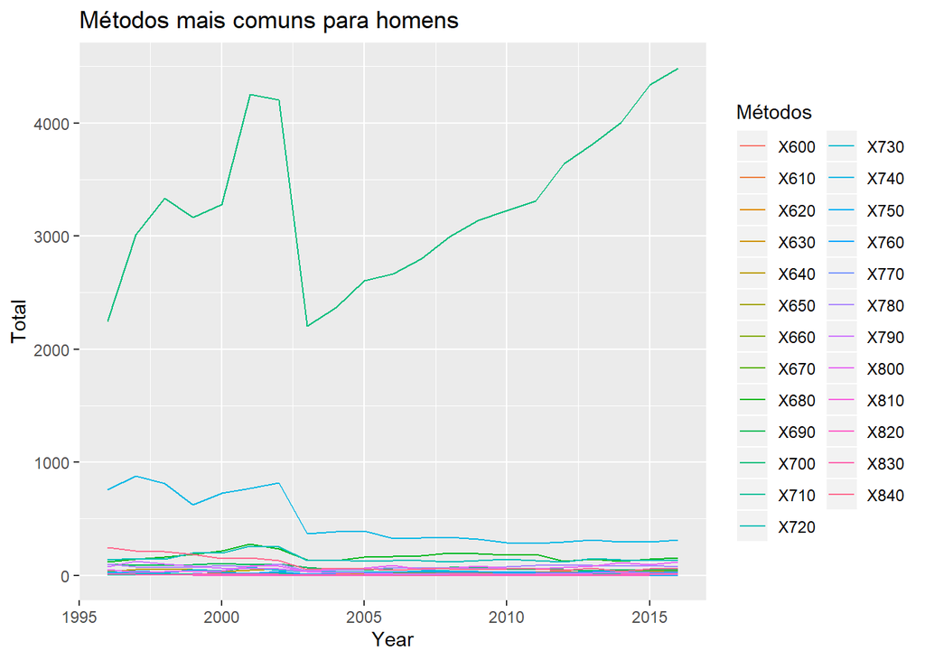

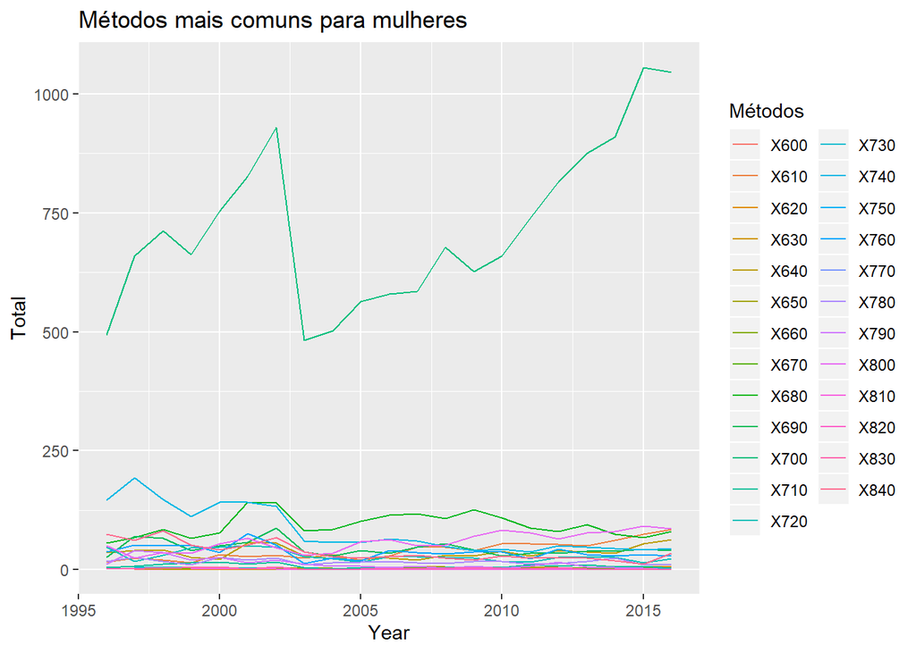

O método mais comum em questão é o mesmo para os dois gêneros, o enforcamento/estrangulamento. Essa forma de suicídio é relativamente comum pela sua facilidade de conseguir materiais e simples execução.

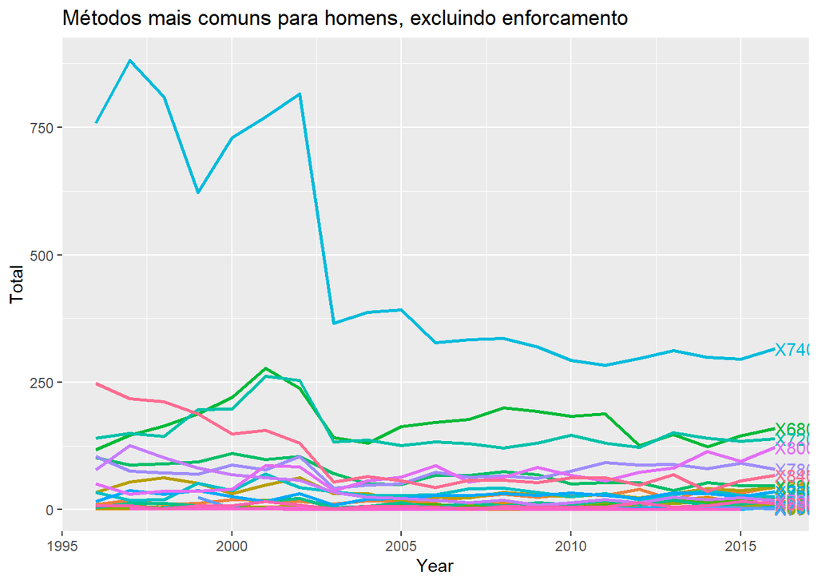

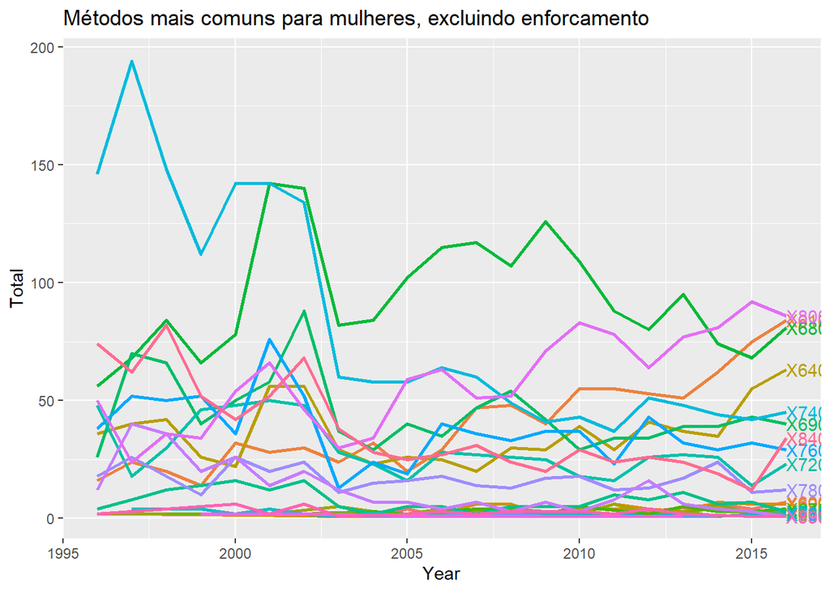

Agora temos diferenças significativas nas formas de suicídio separando por gênero, enquanto os homens optam por “X740”, representando armas de fogo, e bem abaixo temos envenenamento e quedas. As mulheres preferem se suicidar pulando de locais altos e com envenenamento. Essa diferença é um fato importante quando estamos tratando de número de suicídios por gênero, haja vista que armas de fogo apresentam uma chance de sucesso relativamente mais alta do que overdose por remédios, drogas, etc. Contribuindo para os maiores números de suicídios com sucesso pelo sexo masculino. Por outro lado, a quantidade bruta anual não é significativa para indicar que esse seja o único fator resultante nessa discrepância.

Uma observação importante foi a redução drástica no número de suicídios não só com armas de fogo, mas geral do ano de 2003 em diante. O ano da campanha do desarmamento teve um impacto positivo na prevenção ao suicídio no país.

##3 Qual a faixa etária mais suicida?

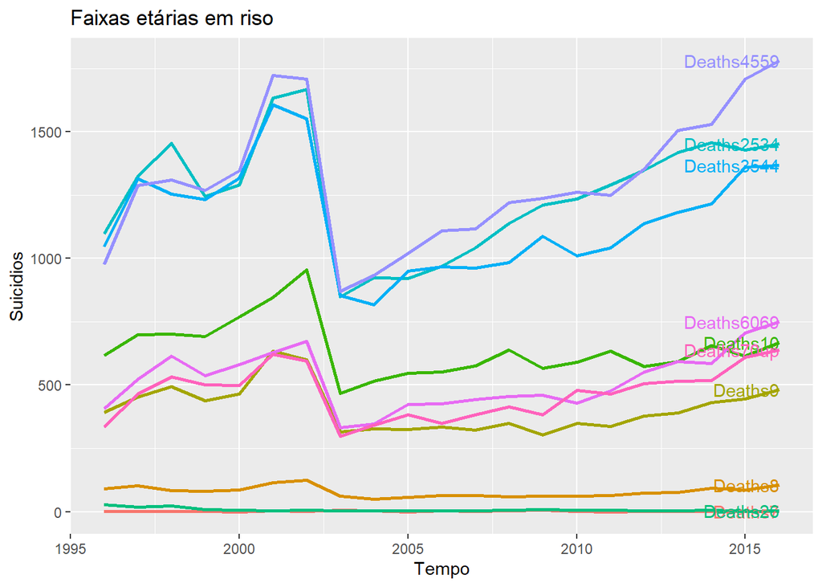

Diferentemente do senso comum, que dita adolescentes e idosos como faixas etárias de risco. o gráfico moestra como pessoas entre 25-59 anos representam significativamente taxas de suicídio elevadas. Essa parcela da sociedade tem mais responsabilidade e normalmente possuem uma rede de apoio reduzida. Fatores estes que contribuem para as taxas de suicídio.

## Conclusão da Análise Exploratória

Com esse relatório é possível deduzir que homens de meia idade são as categorias com mais risco de suicídio. Seus métodos são mais letais do que os das mulheres e o número de pessoas que tiram as suas próprias vidas está aumentando cada vez mais, mesmo após a redução drástica da metade da década de 00.

#Modelagem

Os dados dos suicídios nos últimos anos podem ser vistos da seguinte forma

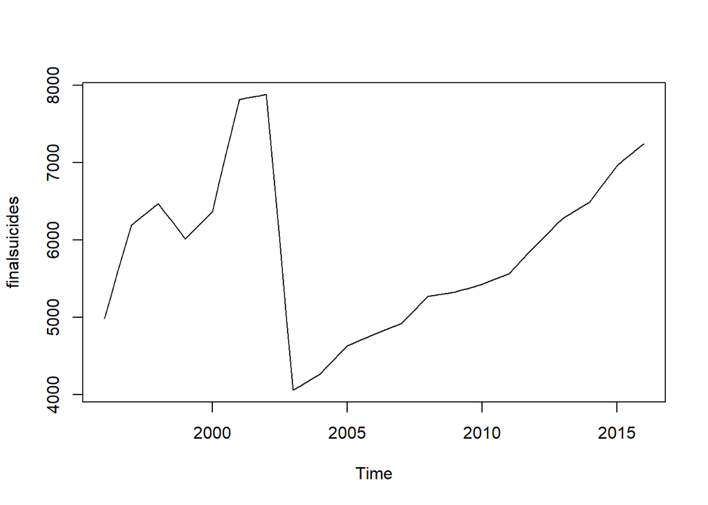

Analisando o gráfico, fica evidente a necessidade de um tratamento desses dados para que seja realizada uma previsão temporal. Dessa forma, vários modelos foram gerados e testados em níveis de diferenciação diferentes.

O BDD trouxe os dados divididos anualmente, dessa forma foi utilizado a interpolação para gerar novos dados trimestrais. Sendo mais fácil de visualizar as previsões realizadas.

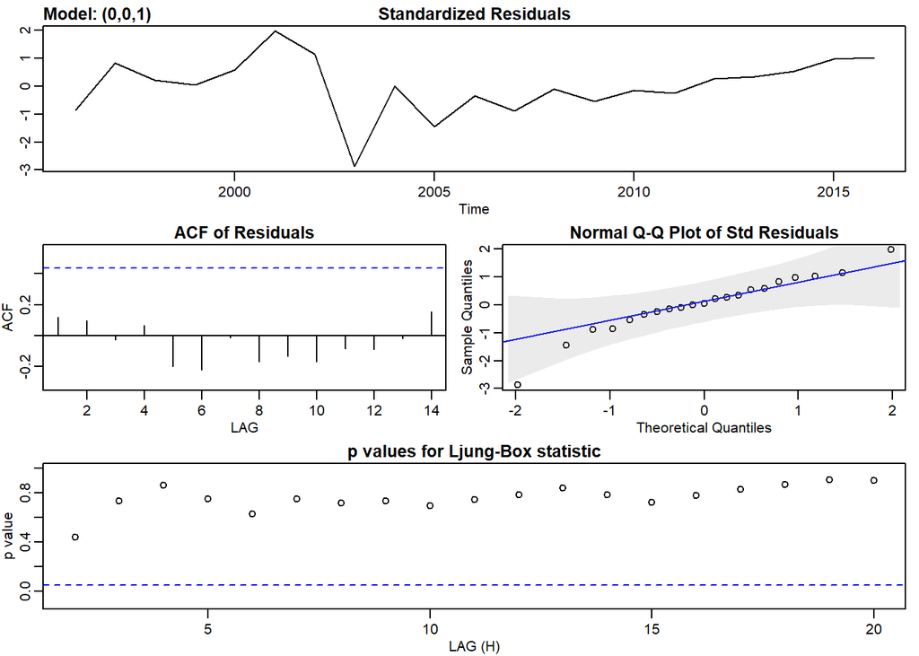

```
## $fit
##
## Call:
## stats::arima(x = xdata, order = c(p, d, q), seasonal = list(order = c(P, D,
##     Q), period = S), xreg = xmean, include.mean = FALSE, transform.pars = trans,
##     fixed = fixed, optim.control = list(trace = trc, REPORT = 1, reltol = tol))
##
## Coefficients:
##          ma1      xmean
##       0.6513  5853.5354
## s.e.  0.1456   297.7915
##
## sigma^2 estimated as 708563:  log likelihood = -171.52,  aic = 349.04
##
## $degrees_of_freedom
## [1] 19
##
## $ttable
##        Estimate       SE t.value p.value
## ma1      0.6513   0.1456  4.4727   3e-04
## xmean 5853.5354 297.7915 19.6565   0e+00
##
## $AIC
## [1] 16.62087
##
## $AICc
## [1] 16.65261
##
## $BIC
## [1] 16.77008
```

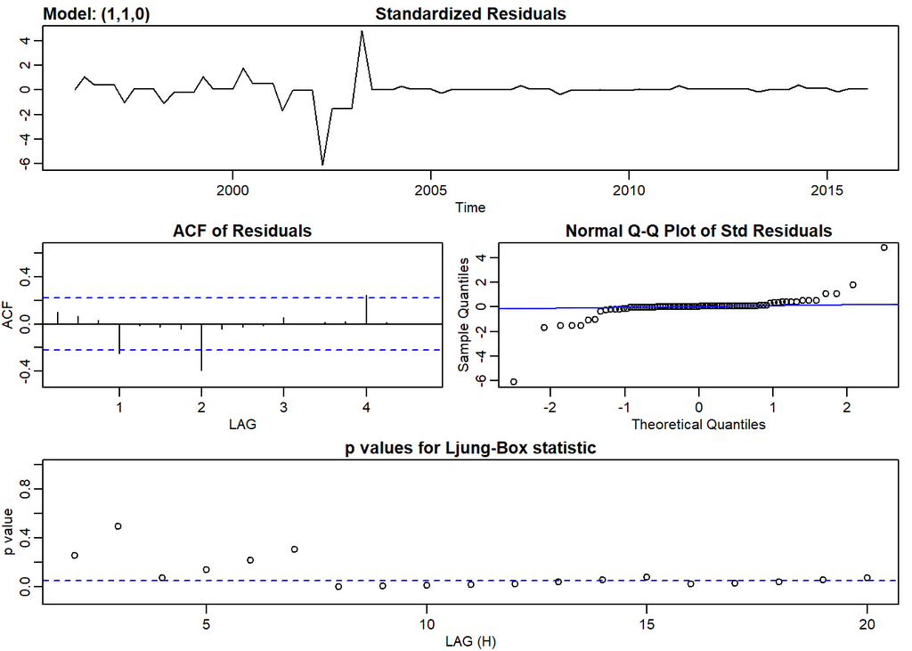

```
## $fit
##
## Call:
## stats::arima(x = xdata, order = c(p, d, q), seasonal = list(order = c(P, D,
##     Q), period = S), xreg = constant, transform.pars = trans, fixed = fixed,
##     optim.control = list(trace = trc, REPORT = 1, reltol = tol))
##
## Coefficients:
##          ar1  constant
##       0.7560   39.6663
## s.e.  0.0717   70.7220
##
## sigma^2 estimated as 25580:  log likelihood = -519.92,  aic = 1045.84
##
## $degrees_of_freedom
## [1] 78
##
## $ttable
##          Estimate      SE t.value p.value
## ar1        0.7560  0.0717 10.5490  0.0000
## constant  39.6663 70.7220  0.5609  0.5765
##
## $AIC
## [1] 13.07304
##
## $AICc
## [1] 13.07499
##
## $BIC
## [1] 13.16237
```

Os dois primeiros apresentaram altas taxas de AIC e BIC, apesar dos gráficos de diferenciação estarem intuitivamente mais corretos. Por outro lado, caso não houvesse nenhuma diferenciação, e a utilização de um modelo SAR(2). As taxas de AIC e BIC se mostraram comparativamente baixas.

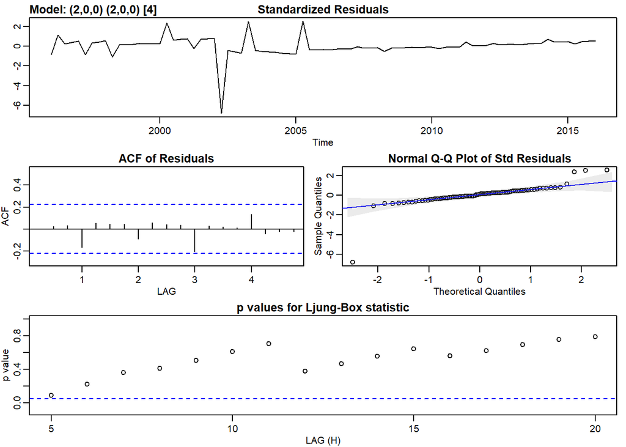

```
## $fit
##
## Call:
## stats::arima(x = xdata, order = c(p, d, q), seasonal = list(order = c(P, D,
##     Q), period = S), xreg = xmean, include.mean = FALSE, transform.pars = trans,
##     fixed = fixed, optim.control = list(trace = trc, REPORT = 1, reltol = tol))
##
## Coefficients:
##          ar1      ar2     sar1     sar2      xmean
##       1.8315  -0.8556  -0.4185  -0.4763  5831.4828
## s.e.  0.0574   0.0576   0.1013   0.0950   307.7356
##
## sigma^2 estimated as 16673:  log likelihood = -512.29,  aic = 1036.59
##
## $degrees_of_freedom
## [1] 76
##
## $ttable
##        Estimate       SE  t.value p.value
## ar1      1.8315   0.0574  31.9065   0e+00
## ar2     -0.8556   0.0576 -14.8628   0e+00
## sar1    -0.4185   0.1013  -4.1321   1e-04
## sar2    -0.4763   0.0950  -5.0121   0e+00
## xmean 5831.4828 307.7356  18.9497   0e+00
##
## $AIC
## [1] 12.79736
##
## $AICc
## [1] 12.80723
##
## $BIC
## [1] 12.97472
```

Ainda assim, os gráficos estão longe do White Noise ideal. Contudo, mesmo havendo uma certa variação na média, não existe uma linha de tendência nos residuals. Já que ele apresenta pouca variação na diferenciação.

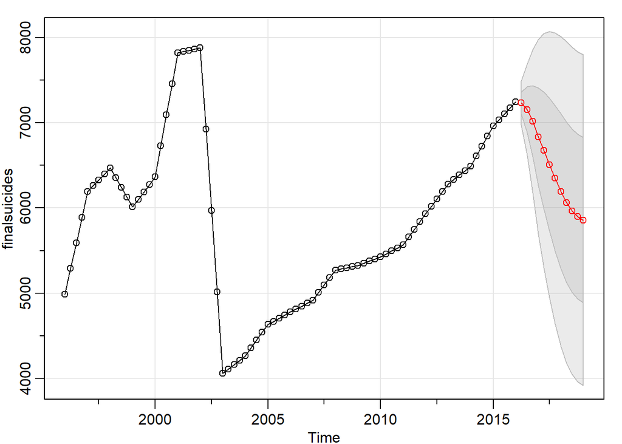

```
## $pred
##          Qtr1     Qtr2     Qtr3     Qtr4
## 2016          7233.649 7154.029 7018.415
## 2017 6836.091 6673.968 6510.192 6349.004
## 2018 6193.965 6064.660 5966.323 5897.824
## 2019 5857.477
##
## $se
##          Qtr1     Qtr2     Qtr3     Qtr4
## 2016          129.1246 269.4431 420.3520
## 2017 572.4306 687.9363 779.3965 852.1287
## 2018 909.3419 942.4989 959.9495 967.6319
## 2019 969.9469
```

A linha de tendência dos últimos dados está claramente positiva, mas os efeitos passados foram um fator importante para prever a queda dos suicídios. Apesar de ainda estarmos com uma grande margem de erro.

##Isso nos leva a questão principal, os grupos de risco estão em perigo? Entenda-se grupos de risco pela faixa da meia-idade. Como visto na análise exploratória

As mesmas análises realizadas para os dados gerais se repetem para a população de meia idade, que segue o mesmo padrão geral. De crescimento nos últimos anos.

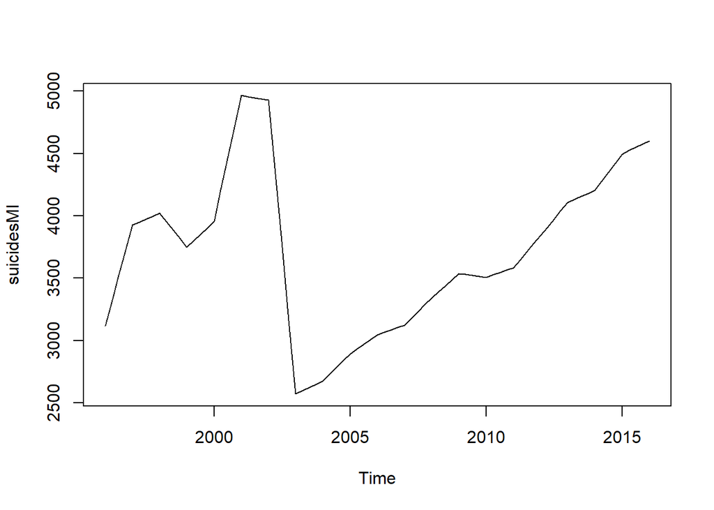

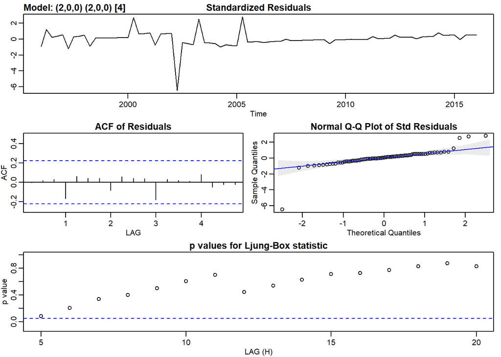

```
## $fit
##
## Call:
## stats::arima(x = xdata, order = c(p, d, q), seasonal = list(order = c(P, D,
##     Q), period = S), xreg = xmean, include.mean = FALSE, transform.pars = trans,
##     fixed = fixed, optim.control = list(trace = trc, REPORT = 1, reltol = tol))
##
## Coefficients:
##          ar1      ar2     sar1     sar2     xmean
##       1.8319  -0.8559  -0.3711  -0.4931  3703.149
## s.e.  0.0575   0.0577   0.1007   0.0940   195.549
##
## sigma^2 estimated as 6434:  log likelihood = -473.82,  aic = 959.64
##
## $degrees_of_freedom
## [1] 76
##
## $ttable
##        Estimate       SE  t.value p.value
## ar1      1.8319   0.0575  31.8761   0e+00
## ar2     -0.8559   0.0577 -14.8227   0e+00
## sar1    -0.3711   0.1007  -3.6840   4e-04
## sar2    -0.4931   0.0940  -5.2464   0e+00
## xmean 3703.1492 195.5490  18.9372   0e+00
##
## $AIC
## [1] 11.84736
##
## $AICc
## [1] 11.85724
##
## $BIC
## [1] 12.02473
```

seguindo o mesmo padrão, uma previsão com o mesmo horizonte foi realizada.

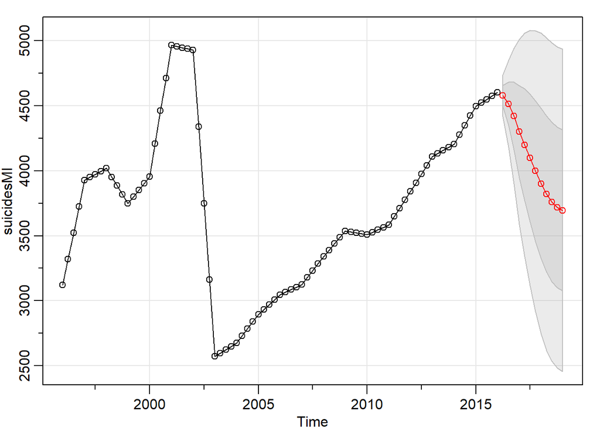

```
## $pred
##          Qtr1     Qtr2     Qtr3     Qtr4
## 2016          4577.658 4515.198 4420.512
## 2017 4299.416 4199.313 4097.856 3997.765
## 2018 3901.335 3820.004 3759.233 3718.021
## 2019 3695.042
##
## $se
##           Qtr1      Qtr2      Qtr3      Qtr4
## 2016            80.21446 167.41341 261.23204
## 2017 355.82568 429.86356 489.93166 538.78248
## 2018 578.07612 600.72452 612.59866 617.80523
## 2019 619.36254
```

##Conclusão da modelagem

Assim sendo, pode-se concluir que nos últimos anos as taxas de suicídos estão em alta e que, apesar dos modelos atuais preverem uma queda decorrente dos resultados históricos. A margem de confiança ainda está ampla o suficiente para mantermos a atenção nos indicadores de suicídio no Brasil.

#Conclusão das Análises

Pode-se interpretar os resultados *estatisticamente* positivos, já que, mesmo com um aumento recente nos suicídios a tendência prevista foi a de uma diminuição. Contudo, pode ser argumentado que as quedas drásticas do número de suicídios em 2003 afetou a qualidade dessa previsão.

Outro ponto relevante foi o impacto que a *política do desarmamento* teve nos suicídios, com uma redução correlacionada ao seu ano de implementação, com o número de suicídios por armas de fogo caindo de forma drásticas. Levando a maior redução nos suicídios masculinos, que utilizam essas ferramentas como uma das principais escolhas no suicídio.

Também foi observado que pessoas entre 25-59 anos cometem significativamente mais suicídios que o resto da população, enquanto recebem menos apoio e políticas direcionadas. Fatores como isolamento social e alienação podem contribuir negativamente para a saúde mental dessas pessoas. Dessa forma, políticas públicas direcionadas a essa faixa etária seriam muito bem vindas.

Analisando as diferenças de gênero, também podemos deduzir que homens tem uma tendência a recorrer a tentativas de suicídios mais “eficazes” como armas de fogo e queda, enquanto mulheres tem uma preferência por envenenamento. Esta diferença também foi considerada como um dos fatores de diferença na taxa entre os gêneros.

Dessa forma, as análises conseguiram trazer informações inicialmente contra intuitivas, que desafiaram a hipótese inicial de que jovens e idosos cometem mais suicídios, e que os gêneros não apresentam diferenças relevantes entre si.